# Projet R 2017

Xian YANG xian.yang@etu.unistra.fr

3 mai, 2017

## Avant propos

Ce document est écrit de façon qu’un rapport du style *Rmarkdown* peut être généré directement du scripte R, lorsqu’il peut également être sourcé comme un document R normal. Pour le sourcer, il est important que votre système soit en français, à cause des carartères spéciaux (bien que les lettres spéciales se trouvent seulement dans les comentaires et que le codage soit mis en UTF-8, R ne les acceptent bizzarement pas lors de la source. Par contre runner toutes les commandes même en une fois ne posera pas de problème). Si ce n’est pas le cas, veuillez exécuter la commande suivante

```r
Sys.setlocale("LC_CTYPE", "fr_FR")
```

L’encodage est mis en UTF-8 pour permettre l’affichage des lettres accentuées. Rouvrez le fichier avec le bon codage si besoin.

## Une note importante

J’ai prévilégié dans l’ensemble du scripte les classes et méthodes S4 que celles S3, c’est notamment à cause du choix personnel, bien que S4 dépasse S3 sous certains aspects (poo, vérification de classe, droit d’accès etc.) et devienne plus compliqué sous certains autres. Cela étant dit, pour faciliter la lecture, j’ai toujours nommé les fonctions d’enjeu au sein des méthodes S4 suivant la nomencloture S3 dès que possible, de telle sorte que une méthode S3 soit également créée qui peut être appelée comme une fonction ordinaire sans forcément passant par la fonction générique. Example :

```r
setMethod(
   f = "is",
   signature = "Polynomial",
   definition = is.Polynomial <- function(object) class(object) == "Polynomial"
)
```

`is.Polynomial <-` est ici redondant. Normalement, S4 ne soutient que d’appeler une méthode à travers sa fonction générique `is(x, "Polynomial")` et non pas genre `is.Polynomial(x)`. Il convient de remarquer que

- ça entraîne une redondance (deux méthodes pour faire la même chose) et que
- ce n’est pas la bonne façon de travailler avec S4. Je fais comme ça seulement pour simplifier la vérification du résultat.

## Hightlights du scripte pour l’impatient

- *Emploi de classes et méthodes S4.*
- *Test complet de chaque fonction avec tout genre d’examples : polynôme 0, polynômes de même degré mais de coeffs dominants de signes opposés qui s’annulent, etc.*
- *Construction d’un polynôme par ses racines sans multiplier mononôme par mononôme.*
- *Utilisation du méchanisme de trois points dans la définition de fonction.*
- *Redéfinition des opérations arithmétiques en passant par leur groupe “Arith”.*
- *Utilisation des paquets “glmnet” et “plotmo” pour Lasso.*
- *Création des fiches aides à l’aide du paquet “roxygen2”.*

## Partie Base polynomiale

Comme le chargement du paquet `polynom` n’est pas souhaité d’après l’esprit de l’ensemble des exercices, la classe `Polynomial` n’existe pas encore. Il convient d’abord de la créer. Ici, le nom de la classe est capitalisé afin de ne pas le confondre avec celui défini dans le paquet `polynom`.

```r
setClass("Polynomial", representation(coeffs = "numeric"))
```

On définit ici également le massage retourné par R à chqaue fois que le contenu d’un objet “Polynomial” est demandé.

```r
setMethod(
  f = "show",
  signature = "Polynomial",
  definition = function(object) {
    cat("Un objet de classe \"Polynomial\" dont les coefficients dans l'ordre croissant sont : \n")
    print(object@coeffs)
  }
)
```

```
## [1] "show"
```

### 1. Création de la fonction “Polynomial” qui crée un objet “Polynomial”.

```r
Polynomial <- function(coeffs, roots = FALSE, dominant = 1) {
  if (roots) stop("La construction d'un polynôme à partir de ses racines n'est pas encore implémentée. ",
                  call. = FALSE) else
                    new("Polynomial", coeffs=coeffs)
}
```

```r
poly1 <- Polynomial(c(1, -2, 3))
poly1
```

```
## Un objet de classe "Polynomial" dont les coefficients dans l'ordre croissant sont :
## [1]  1 -2  3
```

Ceci renvoyera un message d’erreur

`Polynomial(c(1, 2), roots=TRUE)`

### 2. Création de la méthode `is.Polynomial` vérifiant si l’objet est de classe `Polynomial`.

Ici, une méthode pouvant être appelée par la fonction générique `is` est plus pertinente qu’une fonction indépendante. Elle est créée en S3 et en S4.

```r
setMethod(
  f = "is",
  signature = "Polynomial",
  definition = is.Polynomial <- function(object) class(object) == "Polynomial"
)
```

```
## [1] "is"
```

Essayons d’abord avec la méthode elle-même puis avec sa fonction générique “is”.

```r
is.Polynomial(poly1)
```

```
## [1] TRUE
```

```r
is(poly1, "Polynomial")
```

```
## [1] TRUE
```

```r
is.Polynomial(c(1, 2))
```

```
## [1] FALSE
```

### 3. Création de la méthode `as(x, "Polynomial")` convertissant un verteur numérique ou une liste dont le premier élément est un vecteur numérique en un objet `Polynomial`.

*Attention*, car la fonction générique “as” est très particulière (les méthodes S4 se distinguent normalement par leur entrée mais ici, l’enjeu c’est la valeur retournée par chaque méthode de la fonction générique “as”), c’est compliqué de procéder avec la fonction setMethode. En revanche, il existe pour cela la fonction S4 “setAs”, qui permet d’appliquer la coercition sans peine.

On ne vérifie pas si le vecteur ou le premier élément dé-listé est numérique. On laisse ce travail à la fonction “Polynomial” qui renverra à son tour un massage d’erreur en cas d’incompatibilité.

```r
setAs(
  from = "numeric", # pour un vecteur numérique
  to = "Polynomial",
  def = as.Polynomial <- function(from) Polynomial(if (is.list(from)) from[[1]] else from)
)
```

```r
setAs(
  from = "list", # pour une liste
  to = "Polynomial",
  def = as.Polynomial <- function(from) Polynomial(if (is.list(from)) from[[1]] else from)
)
```

On voit bien que grâce à la façon de construction, la méthode existe tant en S3 qu’en S4

```r
as.Polynomial(list(x=c(1, 2)))
```

```
## Un objet de classe "Polynomial" dont les coefficients dans l'ordre croissant sont :
## [1] 1 2
```

```r
as.Polynomial(c(1, 2))
```

```
## Un objet de classe "Polynomial" dont les coefficients dans l'ordre croissant sont :
## [1] 1 2
```

```r
as(c(1, 2), 'Polynomial')
```

```
## Un objet de classe "Polynomial" dont les coefficients dans l'ordre croissant sont :
## [1] 1 2
```

```r
as(list(x=c(1, 2)), 'Polynomial')
```

```
## Un objet de classe "Polynomial" dont les coefficients dans l'ordre croissant sont :
## [1] 1 2
```

```r
## La ligne suivante génère une erreur par la fonction "Polynomial" car le vecteur n'est pas numérique.
## as.Polynomial((x=c('a', 'b')))
```

### 4. Création de la fonction `simplifyPolynomial` qui rend dominant le premier terme de coefficient non nul.

Le paramètre degreVoulu sert à répérer le degré du polynôme renvoyé. Si On veut simplement le polynôme simplyfié, pas besoin de préciser ce paramètre (0 par défaut). Par contre si le degré voulu est plus élevé que celui du polynôme simplyfié, la fonction va le compléter avec des 0 jusqu’à ce degré-là. Cette conception verra son utilité dans la question 11 (opérations arithmétiques).

```r
simplifyPolynomial <- function(x, degreVoulu = 0) {
  longueur <- length(x@coeffs)
  if (longueur - 1 < degreVoulu) {
    x@coeffs <- c(x@coeffs, rep(0, degreVoulu - longueur + 1))
    return (x)
  } else {
    if (longueur == 1) return(x)
    else if (tail(x@coeffs, 1) != 0 || longueur - 1 <= degreVoulu) return(x)
    else {
      x@coeffs <- x@coeffs[-longueur]
      return(simplifyPolynomial(x, degreVoulu))
    }
  }
}
```

Quelques examples

```r
poly1
```

```
## Un objet de classe "Polynomial" dont les coefficients dans l'ordre croissant sont :
## [1]  1 -2  3
```

```r
simplifyPolynomial(poly1)
```

```
## Un objet de classe "Polynomial" dont les coefficients dans l'ordre croissant sont :
## [1]  1 -2  3
```

```r
poly2 <- Polynomial(c(1,-3,2,0,-5,0,0,0))
simplifyPolynomial(poly2)
```

```
## Un objet de classe "Polynomial" dont les coefficients dans l'ordre croissant sont :
## [1]  1 -3  2  0 -5
```

```r
simplifyPolynomial(poly2, degreVoulu = 5)
```

```
## Un objet de classe "Polynomial" dont les coefficients dans l'ordre croissant sont :
## [1]  1 -3  2  0 -5  0
```

```r
simplifyPolynomial(poly2, degreVoulu = 10)
```

```
## Un objet de classe "Polynomial" dont les coefficients dans l'ordre croissant sont :
##  [1]  1 -3  2  0 -5  0  0  0  0  0  0
```

On s’assure également que le polynôme nul est compatible avec la fonction

```r
poly0 <- Polynomial(c(0, 0, 0))
simplifyPolynomial(poly0)
```

```
## Un objet de classe "Polynomial" dont les coefficients dans l'ordre croissant sont :
## [1] 0
```

### 5. Création de la méthode `as.character.Polynomial` qui convertit un polynôme en une chaîne de caractères.

D’abord une fonction `degre` qui renvoie le degré d’un objet `Polynomial`

```r
degre <- function(p) {
  sim_p <- simplifyPolynomial(p)@coeffs
  return(if ((longueur <- length(sim_p)) == 1 & sim_p[1] == 0) -Inf else longueur - 1)
}
```

Essayons avec

```r
poly1
```

```
## Un objet de classe "Polynomial" dont les coefficients dans l'ordre croissant sont :
## [1]  1 -2  3
```

```r
degre(poly1)
```

```
## [1] 2
```

```r
poly2
```

```
## Un objet de classe "Polynomial" dont les coefficients dans l'ordre croissant sont :
## [1]  1 -3  2  0 -5  0  0  0
```

```r
degre(poly2)
```

```
## [1] 4
```

```r
poly0
```

```
## Un objet de classe "Polynomial" dont les coefficients dans l'ordre croissant sont :
## [1] 0 0 0
```

```r
degre(poly0)
```

```
## [1] -Inf
```

```r
## fonction `expression`.
```

```r
as.character.Polynomial <- function(x, expressionStyle = FALSE) {
  sim_x <- rev(simplifyPolynomial(x)@coeffs)
  Deg <- length(sim_x) - 1
  if (Deg == 0) return (as.character(sim_x[Deg+1])) else {
    coeffs_caracteres <- sim_x

    ## Ici le code pour insérer des '*' en cas de besoin.
    if (expressionStyle) {
      signeMulti <- rep("*", Deg+1)
      signeMulti[sim_x %in% c(-1, 1)] <- ""
      signeMulti[Deg+1] <- ""
    }

    coeffs_caracteres[-(Deg+1)][coeffs_caracteres[-(Deg+1)] == 1] <- ""
    coeffs_caracteres[-(Deg+1)][coeffs_caracteres[-(Deg+1)] == -1] <- "-"
    coeffs_caracteres[-1][coeffs_caracteres[-1] > 0 | coeffs_caracteres[-1] == ""] <-
      paste("+", coeffs_caracteres[-1][coeffs_caracteres[-1] > 0 | coeffs_caracteres[-1] == ""], sep="")
    return (
      paste(coeffs_caracteres[sim_x != 0],

            ## Ici le code pour insérer des '*' en cas de besoin.
            if (expressionStyle) signeMulti[sim_x != 0],

            c(rep("x^", Deg - 1), "x", "")[sim_x != 0],
            if (Deg == 1) c("", "")[(sim_x != 0)] else c(Deg:2, "", "")[sim_x != 0], sep = "", collapse = "")
    )
  }
}
```

Maintenant on emballe la fonction dans une méthode

```r
setMethod(
  f = "as.character",
  signature = "Polynomial",
  definition = as.character.Polynomial
)
```

```
## [1] "as.character"
```

Essayons avec quelques examples. A noter que les 1 et les -1 apparaissent comme il faut selon s’ils sont termes constants ou non.

```r
as.character.Polynomial(poly1)
```

```
## [1] "3x^2-2x+1"
```

```r
as.character.Polynomial(poly2)
```

```
## [1] "-5x^4+2x^2-3x+1"
```

```r
as.character.Polynomial(Polynomial(c(0, 1, -1, 1, 0, -1, 2, 0)), expressionStyle = TRUE)
```

```
## [1] "2*x^6-x^5+x^3-x^2+x"
```

```r
as.character.Polynomial(poly0)
```

```
## [1] "0"
```

```r
as.character.Polynomial(Polynomial(c(0, 1)))
```

```
## [1] "x"
```

```r
as.character.Polynomial(Polynomial(c(1, -1)))
```

```
## [1] "-x+1"
```

```r
as.character.Polynomial(Polynomial(-1))
```

```
## [1] "-1"
```

### 6. Création d’une méthode de la fonction générique `print` pour afficher un polynôme à la console.

```r
setMethod(
  f = "print",
  signature = "Polynomial",
  definition = print.Polynomial <- function(x) print(as.character.Polynomial(x), quote = FALSE)
)
```

```
## [1] "print"
```

Essayons avec

```r
print(poly1)
```

```
## [1] 3x^2-2x+1
```

### 7. Création d’une fonction calculant la dérivée d’un polynôme.

```r
derivePolynomial <- function(x) {
  if ((Deg <- degre(x)) <= 0) return (Polynomial(0)) else {
    deriveCoeffs <- simplifyPolynomial(x)@coeffs[-1] * 1:Deg
    return (Polynomial(deriveCoeffs))
  }
}
```

Essayons avec

```r
derivePolynomial(poly1)
```

```
## Un objet de classe "Polynomial" dont les coefficients dans l'ordre croissant sont :
## [1] -2  6
```

```r
derivePolynomial(poly2)
```

```
## Un objet de classe "Polynomial" dont les coefficients dans l'ordre croissant sont :
## [1]  -3   4   0 -20
```

```r
derivePolynomial(poly0)
```

```
## Un objet de classe "Polynomial" dont les coefficients dans l'ordre croissant sont :
## [1] 0
```

### 8. Création d’une fonction calculant la primitive d’un polynôme.

A savoir que la constante C ajoutée est 0.

```r
primitivePolynomial <- function(p) {
  if ((Deg <- degre(p)) == -Inf) return (Polynomial(0)) else {
    primitiveCoeffs <- c(0, simplifyPolynomial(p)@coeffs / 1:(Deg + 1))
    return (Polynomial(primitiveCoeffs))
  }
}
```

Essayons avec

```r
primitivePolynomial(poly1)
```

```
## Un objet de classe "Polynomial" dont les coefficients dans l'ordre croissant sont :
## [1]  0  1 -1  1
```

```r
primitivePolynomial(poly2)
```

```
## Un objet de classe "Polynomial" dont les coefficients dans l'ordre croissant sont :
## [1]  0.0000000  1.0000000 -1.5000000  0.6666667  0.0000000 -1.0000000
```

```r
primitivePolynomial(poly0)
```

```
## Un objet de classe "Polynomial" dont les coefficients dans l'ordre croissant sont :
## [1] 0
```

### 9. Création d’une fonction évaluant un polynôme en un ou plusieurs points donnés.

A noter qu’ici le calcul vectoriel (x est un vecteur représentant plusieurs points) est soutenu.

```r
values <- function(p, x) {
  sapply(x,
         function(poly, y) {
           sim_p <- simplifyPolynomial(poly)@coeffs
           if ((Deg <- degre(poly)) <= 0) return (sim_p[1]) else
             return ((sim_p)[1] + sum(sim_p[-1] * y^(1:Deg)))
         },
         poly = p
  )
}
```

Essayons avec

```r
poly1
```

```
## Un objet de classe "Polynomial" dont les coefficients dans l'ordre croissant sont :
## [1]  1 -2  3
```

```r
values(p=poly1, x=c(1, 2))
```

```
## [1] 2 9
```

```r
poly2
```

```
## Un objet de classe "Polynomial" dont les coefficients dans l'ordre croissant sont :
## [1]  1 -3  2  0 -5  0  0  0
```

```r
values(poly2, c(0, -1, -2))
```

```
## [1]   1   1 -65
```

```r
values(poly0, c(0, 0))
```

```
## [1] 0 0
```

### 10. Création d’une fonction calculant l’intégrale d’un polynôme entre [-1, 1].

A noter que le calcul se fait à travers la primitive du polynôme et que xmin peut être plus petit, égal, ou plus grand que xmax.

```r
integratePolynomial <- function(p, xmin, xmax) diff(values(primitivePolynomial(p), c(xmin, xmax)))
```

Essayons avec

```r
poly1
```

```
## Un objet de classe "Polynomial" dont les coefficients dans l'ordre croissant sont :
## [1]  1 -2  3
```

```r
primitivePolynomial(poly1)
```

```
## Un objet de classe "Polynomial" dont les coefficients dans l'ordre croissant sont :
## [1]  0  1 -1  1
```

```r
integratePolynomial(poly1, 1, 2)
```

```
## [1] 5
```

```r
integratePolynomial(poly1, 2, 1)
```

```
## [1] -5
```

```r
integratePolynomial(poly1, 1, 1)
```

```
## [1] 0
```

```r
integratePolynomial(poly0, 3, 10)
```

```
## [1] 0
```

### 11. Création des méthodes pour `+`, `-` et `*` permettant l’addition, la soustraction et la multiplication

entre polynômes.

*Attention* : A la 1ère fois j’ai fait cet exercice en créant des méthodes S4 resp. pour `+`, `-` et `*`, dont j’ai mis le code en commentaires à la fin du scripte. Ça a marché sans aucun souci en premier temps. Cependant, lorsque j’utilise la fonction “cv.glmnet” du paquet “glmnet” dans la question 23, R retourne une erreur car cette fonction-là surcharge également la fonction `+` pour sa nouvelle classe `Matrix` et la méthode rentre en conflict avec la mienne ! En outre, surcharger séparémént les fonctions génériquse `+`, `-` et `*` n’est en effet pas la bonne façon de travailler avec les méthodes S4 car il s’agit d’un GROUPE de fonctions générique. La bonne façon pour S4 est de surcharger le groupe générique “Arith”, d’où il faudra un traitement intégral de toutes les opérations arithmétiques dont on a besoin dans l’ensemble du scripte. Pour cela, j’ai regroupé les exercices 11 et 16 et invite le lecteur à trouver la réponse de cet exercice à la place de l’exercice 16 (Division euclidienne entre polynômes).

### 12. Redéfinition de la classe `Polynomial` et de la fonction de création `Polynomial`.

On va d’abord redéfinir la classe `Polynomial` en y ajoutant un slot `racines`.

```r
setClass("Polynomial", representation(coeffs = "numeric", racines = "numeric"), prototype(racines = NA_integer_))
```

Renouvellement de la fonction de création “Polynomial” qui crée maintenant un objet “Polynomial” à travers ses coefficients ou ses racines.

```r
Polynomial <- function(num, roots = FALSE, dominant = 1) {
  if (roots) {
    coeffs <- sapply(length(num):1, function(x) sum(apply(combn(num, x), 2, prod)))
    new("Polynomial", coeffs = dominant * c(coeffs, 1), racines = sort(num))
  } else
    new("Polynomial", coeffs = num)
}
```

Essayons avec quelques examples

```r
poly3 <- Polynomial(c(1,2), roots = TRUE)
print(poly3)
```

```
## [1] x^2+3x+2
```

```r
poly4 <- Polynomial(c(-1,-1), roots = TRUE, dominant = 5)
print(poly4)
```

```
## [1] 5x^2-10x+5
```

```r
poly5 <- Polynomial(c(0,0), roots = TRUE)
print(poly5)
```

```
## [1] x^2
```

```r
poly6 <- Polynomial(c(0,0,1), roots = TRUE)
print(poly6)
```

```
## [1] x^3+x^2
```

Il convient également de redfinir la façon d’afficher un objet polynomial.

```r
setMethod(
  f = "show",
  signature = "Polynomial",
  definition = function(object) {
    cat("Un objet de classe \"Polynomial\" dont les coefficients dans l'ordre croissant sont : \n")
    print(object@coeffs)
    if (is.na(object@racines[1])) cat("Mais ses racines ne sont pas connues. \n") else {
      cat("Et ses racines sont : \n")
      print(object@racines)
    }
  }
)
```

```
## [1] "show"
```

Il convient de réinitialiser les polynômes créés avec l’ancienne classe.

```r
poly1 <- Polynomial(c(1, -2, 3))
poly2 <- Polynomial(c(1,-3,2,0,-5,0,0,0))
poly0 <- Polynomial(0)
poly1
```

```
## Un objet de classe "Polynomial" dont les coefficients dans l'ordre croissant sont :
## [1]  1 -2  3
## Mais ses racines ne sont pas connues.
```

```r
poly2
```

```
## Un objet de classe "Polynomial" dont les coefficients dans l'ordre croissant sont :
## [1]  1 -3  2  0 -5  0  0  0
## Mais ses racines ne sont pas connues.
```

La fonction `simplifyPolynomial` est-elle toujours opérationnelle ? (Qui ne doit pas perdre les racines en cas d’existence)

```r
poly6
```

```
## Un objet de classe "Polynomial" dont les coefficients dans l'ordre croissant sont :
## [1] 0 0 1 1
## Et ses racines sont :
## [1] 0 0 1
```

```r
poly6@coeffs <- c(0, 0, 1, 1, 0, 0, 0)
simplifyPolynomial(poly6)
```

```
## Un objet de classe "Polynomial" dont les coefficients dans l'ordre croissant sont :
## [1] 0 0 1 1
## Et ses racines sont :
## [1] 0 0 1
```

```r
simplifyPolynomial(poly6, degreVoulu = 10) ## Réponse : oui.
```

```
## Un objet de classe "Polynomial" dont les coefficients dans l'ordre croissant sont :
##  [1] 0 0 1 1 0 0 0 0 0 0 0
## Et ses racines sont :
## [1] 0 0 1
```

Il conviendrait aussi de redéfinir la fonction `primitivePolynomial`, Pour la garde des racines si les opérandes en ont. Mais vu qu’on s’en servira pas par la suite, ici on ne va pas le faire.

### 13. Création d’une méthode pour `summary` qui affiche les coeffs et les racines d’un polynôme.

```r
setMethod(
  f = "summary",
  signature = "Polynomial",
  definition = function(object) {
    return (list(coeffs = object@coeffs, racines = object@racines))
  }
)
```

```
## [1] "summary"
```

Essayons avec

```r
summary(poly6)
```

```
## $coeffs
## [1] 0 0 1 1 0 0 0
##
## $racines
## [1] 0 0 1
```

```r
summary(poly1)$coeffs
```

```
## [1]  1 -2  3
```

### 14. Creation d’une méthode pour `plot` qui trace un polynôme.

```r
setMethod(
  f = "plot",
  signature = "Polynomial",
  definition = plot.Polynomial <- function(x, xlim=c(-1,1), main = "Trace polyn\U00F4miale",
                                           xlab = parse(text = as.character.Polynomial(x, expressionStyle = TRUE)),
                                           ylab = "", col="darkblue", lwd=2, ...) {
    courbe <- function(y) values(x, y)
    plot(courbe, xlim = xlim, main = main, xlab = xlab, ylab = ylab, col=col, lwd=lwd, ...)
  }
)
```

```
## [1] "plot"
```

Essayons avec

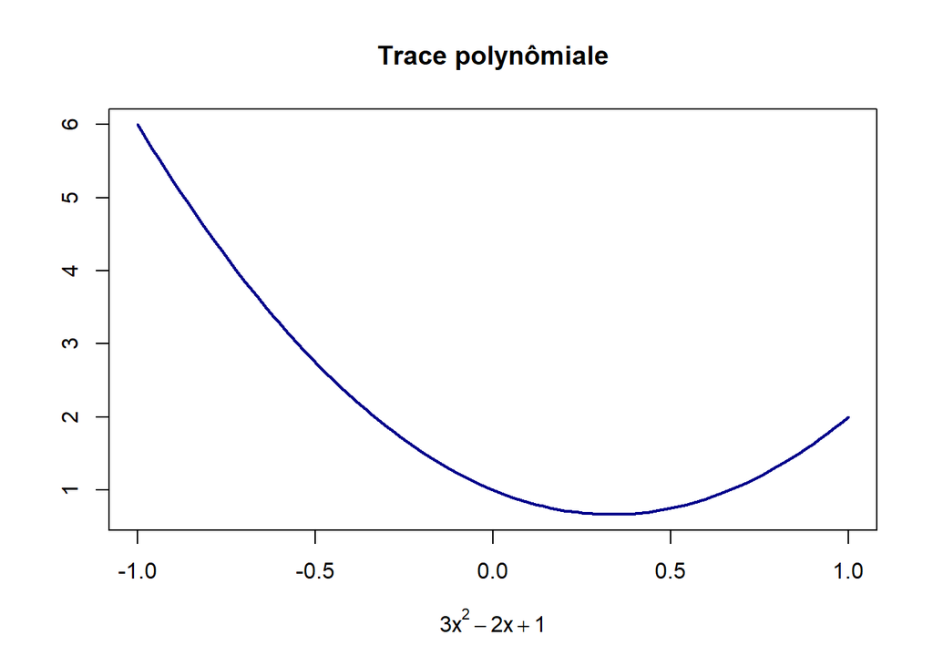

```r
plot.Polynomial(poly1)
```

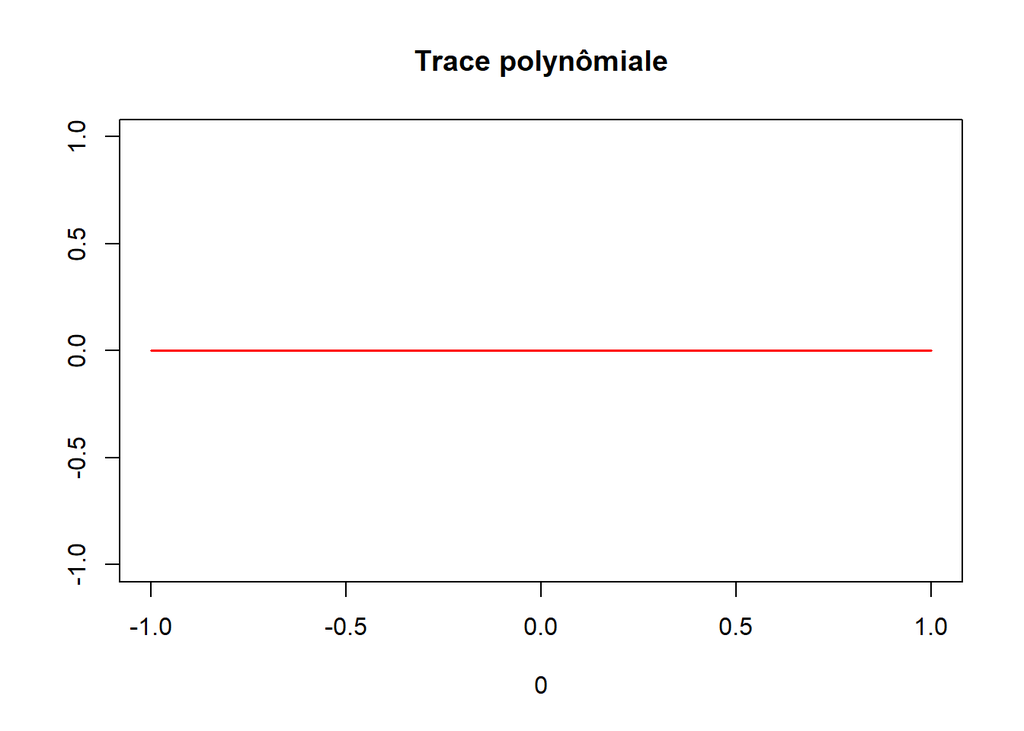

```r
plot(poly0, col='red', lwd=1.5)
```

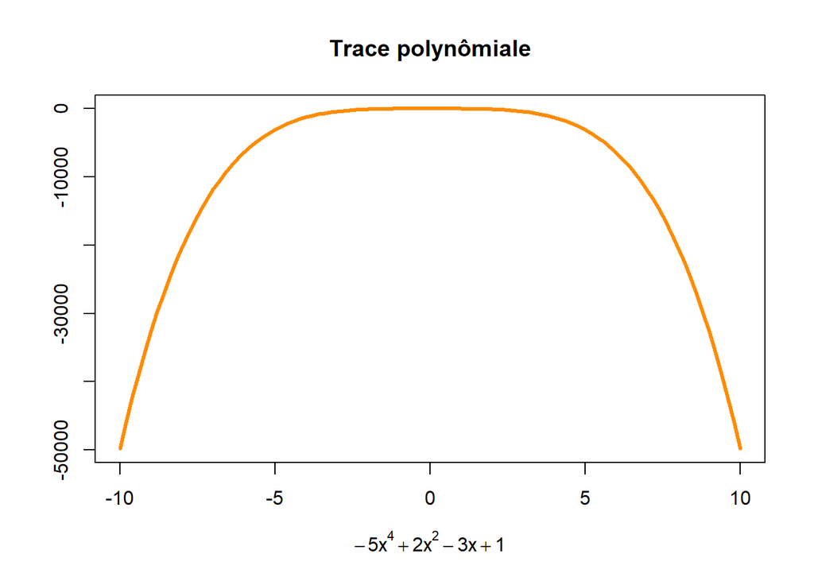

```r
plot(poly2, col="darkorange", lwd=3, xlim=c(-10, 10))
```

### 15. Surcharger la fonction `lines` pour ajouter d’autres traces polynomiales.

*Attention* : On ne va pas créer la fonction `lines.Polynomial`, dont on ne servira pas de toute façon. Pour ajouter une autre courbe à un plot existant, il suffirera d’utiliser `plot.Polynomial` avec le paramètre add = TRUE. Pourquoi cela marche ?

Quand on fait appel à la méthode `plot.Polynomial`, sa fonction générique va chercher la méthode `plot.function` au lieu de `plot.default` qui va à son tour faire appel à la méthode `plot.xy`, parce que notre méthode `plot.Polynomial` est construite de manière qu’elle prenne une fonction comme entrée et non pas un couple de vecteurs numériques. Du coup `plot.function` accepte add=TRUE comme paramètre alors que ce n’est pas le cas de `plot.xy` !

Essayons avec

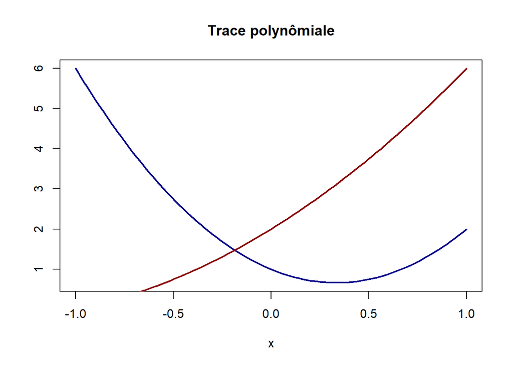

```r
plot.Polynomial(poly1, xlab = NULL)
plot.Polynomial(poly3, xlab = NULL, add=TRUE, col="darkred")
```

### 11. et 16. Opérations arithmétiques polynomiales et entre un polynôme et un nombre.

Maintenant toutes les opérations arithmétiques polynomiales ensembles.

1. Opérations polynomiales binaires

```r
setMethod(
  f = "Arith",
  signature (e1 = "Polynomial", e2 = "Polynomial"),
  definition = function(e1, e2) {

    ## addition ##
    ## Rappelez-vous du paramètre "d'en trop" "degreVoulu" dans la fonction simplifyPolynomial(), dont le but est de
    ## compléter un polynôme avec des 0 à un degré donné plus élevé que celui du polynôme. Maintenant on va s'en servir
    ## pour éviter le mécanisme du recyclage des opérations vectorielles de R.
    if (as.character(match.call()[[1]]) == "+") {
      maxDeg <- max(degre(e1), degre(e2))
      e1 <- simplifyPolynomial(e1, degreVoulu = maxDeg)
      e2 <- simplifyPolynomial(e2, degreVoulu = maxDeg)
      resultat_coeffs <- callGeneric(e1@coeffs, e2@coeffs)
      return (simplifyPolynomial(Polynomial(resultat_coeffs)))
    } else

      ## Soustraction ##
      ## Exactement le même code sauf "-" au lieu de "+".
      if (as.character(match.call()[[1]]) == "-") {
        maxDeg <- max(degre(e1), degre(e2))
        e1 <- simplifyPolynomial(e1, degreVoulu = maxDeg)
        e2 <- simplifyPolynomial(e2, degreVoulu = maxDeg)
        resultat_coeffs <- callGeneric(e1@coeffs, e2@coeffs)
        return (simplifyPolynomial(Polynomial(resultat_coeffs)))
      } else

        ## Multiplication ##
        ## Il y a des algorithmes efficaces dédiés au calcul de la multiplication polynomiale en informatique,
        ## e.g. celui de "diviser pour régner". Ici on ne va pas le faire, puisque
        ## 1. R n'est de toute façon pas un logiciel très efficace, d'où de couper un polynôme en morceaux va prendre du temps
        ## 2. On ne va pas faire de la multiplication avec des polynômes gigantesques, le temps gagné sera pas remarquable.
        ## Donc ici, on le fait avec des boules.
        if (as.character(match.call()[[1]]) == "*") {
          Deg1 <- degre(e1)
          Deg2 <- degre(e2)
          if (Deg1 == -Inf || Deg2 == -Inf) return (Polynomial(0)) else {
            DegResultat <- Deg1 + Deg2
            coeffs1 <- simplifyPolynomial(e1)@coeffs
            coeffs2 <- simplifyPolynomial(e2)@coeffs
            resultat_coeffs <- numeric(DegResultat + 1)
            for (i in 1:(Deg1+1))
              for (j in 1:(Deg2+1))
                resultat_coeffs[i+j-1] <- resultat_coeffs[i+j-1] + coeffs1[i] * coeffs2[j]
            return (Polynomial(resultat_coeffs))
          }
        } else

          ## Résidu ##
          if (as.character(match.call()[[1]]) == "%/%")  {
            if (degre(e2) == -Inf) stop("Diviseur ne doit pas être nul !") else
              if (degre(e2) == 0) return (Polynomial(0)) else {
                coeffs1 <- simplifyPolynomial(e1)@coeffs
                coeffs2 <- simplifyPolynomial(e2)@coeffs
                if (length(coeffs1) < length(coeffs2) || length(coeffs1) == 0) {
                  e1@racines <- NA_integer_
                  return (simplifyPolynomial(e1))
                } else {
                  e1@coeffs <- coeffs1 - c(rep(0, length(coeffs1) - length(coeffs2)),
                                           tail(coeffs1, 1) / tail(coeffs2, 1) * coeffs2)
                  return (simplifyPolynomial(e1) %/% e2)
                }
              }
          } else

            ## Quotient ##
            if (as.character(match.call()[[1]]) == "%%") {
              if (degre(e2) == -Inf) stop("Diviseur ne doit pas être nul !") else {
                coeffs1 <- simplifyPolynomial(e1)@coeffs
                coeffs2 <- simplifyPolynomial(e2)@coeffs
                if (length(coeffs1) < length(coeffs2) || (length(coeffs1) == 1 && coeffs1[1] == 0)) return (Polynomial(0)) else {
                  Deg_diff <- length(coeffs1) - length(coeffs2)
                  Quotient_coeff_dominant <- tail(coeffs1, 1) / tail(coeffs2, 1)
                  e1@coeffs <- coeffs1 - c(rep(0, Deg_diff), Quotient_coeff_dominant * coeffs2)
                  return (Polynomial(c(rep(0, Deg_diff), Quotient_coeff_dominant)) + (simplifyPolynomial(e1) %% e2))
                }
              }
            } else

              ## Autre opération ##
              stop("Cette opération est non définie entre les polynômes !")
  }
)
```

```
## [1] "Arith"
```

2. Opérations polynomiales unaires

```r
setMethod(
  f = "Arith",
  signature (e1 = "Polynomial"),
  definition = function(e1) {
    e1@coeffs <- callGeneric(e1@coeffs)
    return (simplifyPolynomial(e1))
  }
)
```

```
## [1] "Arith"
```

Vérifions maintenant les méthodes avec une série d’examples.

- Addition

```r
poly1 ; poly2
```

```
## Un objet de classe "Polynomial" dont les coefficients dans l'ordre croissant sont :
## [1]  1 -2  3
## Mais ses racines ne sont pas connues.
```

```
## Un objet de classe "Polynomial" dont les coefficients dans l'ordre croissant sont :
## [1]  1 -3  2  0 -5  0  0  0
## Mais ses racines ne sont pas connues.
```

```r
poly1 + poly2
```

```
## Un objet de classe "Polynomial" dont les coefficients dans l'ordre croissant sont :
## [1]  2 -5  5  0 -5
## Mais ses racines ne sont pas connues.
```

```r
+ poly2
```

```
## Un objet de classe "Polynomial" dont les coefficients dans l'ordre croissant sont :
## [1]  1 -3  2  0 -5
## Mais ses racines ne sont pas connues.
```

```r
+ poly0
```

```
## Un objet de classe "Polynomial" dont les coefficients dans l'ordre croissant sont :
## [1] 0
## Mais ses racines ne sont pas connues.
```

```r
poly0 + poly0
```

```
## Un objet de classe "Polynomial" dont les coefficients dans l'ordre croissant sont :
## [1] 0
## Mais ses racines ne sont pas connues.
```

- Soustraction

```r
poly1 ; poly2
```

```
## Un objet de classe "Polynomial" dont les coefficients dans l'ordre croissant sont :
## [1]  1 -2  3
## Mais ses racines ne sont pas connues.
```

```
## Un objet de classe "Polynomial" dont les coefficients dans l'ordre croissant sont :
## [1]  1 -3  2  0 -5  0  0  0
## Mais ses racines ne sont pas connues.
```

```r
poly1 - poly2
```

```
## Un objet de classe "Polynomial" dont les coefficients dans l'ordre croissant sont :
## [1] 0 1 1 0 5
## Mais ses racines ne sont pas connues.
```

```r
- poly2
```

```
## Un objet de classe "Polynomial" dont les coefficients dans l'ordre croissant sont :
## [1] -1  3 -2  0  5
## Mais ses racines ne sont pas connues.
```

```r
- poly0
```

```
## Un objet de classe "Polynomial" dont les coefficients dans l'ordre croissant sont :
## [1] 0
## Mais ses racines ne sont pas connues.
```

```r
poly0 - poly0
```

```
## Un objet de classe "Polynomial" dont les coefficients dans l'ordre croissant sont :
## [1] 0
## Mais ses racines ne sont pas connues.
```

- Multipliacation

```r
poly1; poly2
```

```
## Un objet de classe "Polynomial" dont les coefficients dans l'ordre croissant sont :
## [1]  1 -2  3
## Mais ses racines ne sont pas connues.
```

```
## Un objet de classe "Polynomial" dont les coefficients dans l'ordre croissant sont :
## [1]  1 -3  2  0 -5  0  0  0
## Mais ses racines ne sont pas connues.
```

```r
poly1 * poly2
```

```
## Un objet de classe "Polynomial" dont les coefficients dans l'ordre croissant sont :
## [1]   1  -5  11 -13   1  10 -15
## Mais ses racines ne sont pas connues.
```

```r
poly0 * poly0
```

```
## Un objet de classe "Polynomial" dont les coefficients dans l'ordre croissant sont :
## [1] 0
## Mais ses racines ne sont pas connues.
```

```r
poly0 * poly1
```

```
## Un objet de classe "Polynomial" dont les coefficients dans l'ordre croissant sont :
## [1] 0
## Mais ses racines ne sont pas connues.
```

- Calcul du residu

```r
Polynomial(c(1, 3, -1, 1), roots = TRUE) %/% Polynomial(c(5, 10, 5))
```

```
## Un objet de classe "Polynomial" dont les coefficients dans l'ordre croissant sont :
## [1] 0
## Mais ses racines ne sont pas connues.
```

```r
Polynomial(c(1, 0, -2, 0, 0, 3, -5, -6, -8)) %/% Polynomial(c(3, -5, -6, -8))
```

```
## Un objet de classe "Polynomial" dont les coefficients dans l'ordre croissant sont :
## [1]  1  0 -2
## Mais ses racines ne sont pas connues.
```

```r
poly1
```

```
## Un objet de classe "Polynomial" dont les coefficients dans l'ordre croissant sont :
## [1]  1 -2  3
## Mais ses racines ne sont pas connues.
```

```r
poly1 %/% Polynomial(2)
```

```
## Un objet de classe "Polynomial" dont les coefficients dans l'ordre croissant sont :
## [1] 0
## Mais ses racines ne sont pas connues.
```

```r
## Cette commande renvoyera une erreur
## poly1 %/% poly0
```

- Calcul du quotient

```r
Polynomial(c(1, -1, 1), roots = TRUE) %% Polynomial(c(1, 1), roots = TRUE)
```

```
## Un objet de classe "Polynomial" dont les coefficients dans l'ordre croissant sont :
## [1] -1  1
## Mais ses racines ne sont pas connues.
```

```r
Polynomial(c(1, 0, -2, 0, 0, 3, -5, -6, -8)) %% Polynomial(c(3, -5, -6, -8))
```

```
## Un objet de classe "Polynomial" dont les coefficients dans l'ordre croissant sont :
## [1] 0 0 0 0 0 1
## Mais ses racines ne sont pas connues.
```

```r
poly1
```

```
## Un objet de classe "Polynomial" dont les coefficients dans l'ordre croissant sont :
## [1]  1 -2  3
## Mais ses racines ne sont pas connues.
```

```r
poly1 %% Polynomial(2)
```

```
## Un objet de classe "Polynomial" dont les coefficients dans l'ordre croissant sont :
## [1]  0.5 -1.0  1.5
## Mais ses racines ne sont pas connues.
```

```r
## Cette commande renvoyera une erreur
## poly1 %% poly0
```

3. Ensuite, au lieu de convertir à chaque fois le diviseur numérique en polynôme puis faire la division polynomiale, il convient de définir la division et la multiplication d’un polynôme par un nombre, pour des raisons d’efficacité de calcul.

```r
setMethod(
  f = "Arith",
  signature (e1 = "Polynomial", e2 = "numeric"),
  definition = function(e1, e2) {

    ## Division par un monbre ##
    if (as.character(match.call()[[1]]) == "/") {
      if (e2 == 0) stop("Diviseur ne doit pas être nul !") else {
        e1@coeffs <- e1@coeffs / e2
        return (simplifyPolynomial(e1))
      }
    } else

      ## Multiplication par un monbre ##
      if (as.character(match.call()[[1]]) == "*") {
        e1@coeffs <- e1@coeffs * e2
        return (simplifyPolynomial(e1))
      } else

        ## Autre opération ##
        stop("Cette opération est non définie entre les polynômes !")
  }
)
```

```
## [1] "Arith"
```

```r
poly1 / 0.5
```

```
## Un objet de classe "Polynomial" dont les coefficients dans l'ordre croissant sont :
## [1]  2 -4  6
## Mais ses racines ne sont pas connues.
```

```r
poly2 * 2
```

```
## Un objet de classe "Polynomial" dont les coefficients dans l'ordre croissant sont :
## [1]   2  -6   4   0 -10
## Mais ses racines ne sont pas connues.
```

```r
setMethod(
  f = "Arith",
  signature (e1 = "numeric", e2 = "Polynomial"),
  definition = function(e1, e2) {

    ## Multiplication par un nombre ##
    if (as.character(match.call()[[1]]) == "*") {
      e2@coeffs <- e1 * e2@coeffs
      return (simplifyPolynomial(e2))
    } else

      ## Autre opération ##
      stop("Cette opération est non définie entre les polynômes !")
  }
)
```

```
## [1] "Arith"
```

```r
2 * poly2
```

```
## Un objet de classe "Polynomial" dont les coefficients dans l'ordre croissant sont :
## [1]   2  -6   4   0 -10
## Mais ses racines ne sont pas connues.
```

### 17. Création d’une fonction qui renvoie une base polynomiale, ortho-normée ou non.

Ecrions d’abord une méthode pour `sum` qui prend comme paramètre une liste de listes chacune composée d’un seul polynôme et calcule leur somme. Ce qui rendra le prochain morceaux du code beaucoup plus lisible.

```r
.sum_def <- function(x, ..., na.rm = FALSE) base::sum(x, ..., na.rm = na.rm)
setGeneric("sum", function(x, ..., na.rm = FALSE) standardGeneric("sum"), useAsDefault = .sum_def, group="Summary")
```

```
## Creating a new generic function for 'sum' in the global environment
```

```
## [1] "sum"
```

```r
setMethod(
  f = "sum",
  signature (x = "list", na.rm = "ANY"),
  definition = function(x, ..., na.rm) {
    if (length(x) == 0) return (Polynomial(0)) else
      if (length(x) == 1) return (simplifyPolynomial(x[[1]])) else
        return (simplifyPolynomial(x[[1]] + sum(x[-1])))
  }
)
```

```
## [1] "sum"
```

Essayons simplement avec

```r
poly1
```

```
## Un objet de classe "Polynomial" dont les coefficients dans l'ordre croissant sont :
## [1]  1 -2  3
## Mais ses racines ne sont pas connues.
```

```r
sum(list(poly1, poly1, poly1, poly1))
```

```
## Un objet de classe "Polynomial" dont les coefficients dans l'ordre croissant sont :
## [1]  4 -8 12
## Mais ses racines ne sont pas connues.
```

Maintenant la fonction qui donne la base

```r
basePolynomial <- function(d, ortho=FALSE) {
  nouvelleComposante <- Polynomial(c(rep(0, d-1), 1))
  if (d <= 1) return (list(nouvelleComposante / if (!ortho) 1 else sqrt(2))) else {
    basePrecedente <- basePolynomial(d-1, ortho)
    if (ortho) {
      diminuteur <- sum(lapply(basePrecedente, function(p, p1) integratePolynomial(p * p1, -1, 1) * p,
                               p1 = nouvelleComposante))
      nouvelleComposante <- nouvelleComposante - diminuteur
      nouvelleComposante <- nouvelleComposante / sqrt (integratePolynomial(nouvelleComposante * nouvelleComposante, -1, 1))
    }
    return (c(basePrecedente, nouvelleComposante))
  }
}
```

Un example de base non orthogonale

```r
basePolynomial(3)
```

```
## [[1]]
## [1] 1
##
## [[2]]
## [1] x
##
## [[3]]
## [1] x^2
```

Puis un example de base ortho-normée

```r
BasePoly4 <- basePolynomial(4, ortho=TRUE)
BasePoly4
```

```
## [[1]]
## [1] 0.707106781186547
##
## [[2]]
## [1] 1.22474487139159x
##
## [[3]]
## [1] 2.37170824512628x^2-0.790569415042095
##
## [[4]]
## [1] 4.67707173346743x^3-2.80624304008046x
```

Vérifions que la base est bien ortho-normée

```r
sapply(BasePoly4, function(x) integratePolynomial(x*x, -1, 1)) # doit renvoyer : [1] 1 1 1 1
```

```
## [1] 1 1 1 1
```

```r
apply(combn(BasePoly4, 2), 2, function(x) integratePolynomial(x[[1]]*x[[2]], -1, 1)) # doit renvoyer : [1] 0 0 0 0 0 0
```

```
## [1] 0.000000e+00 2.220446e-16 0.000000e+00 0.000000e+00 4.440892e-16
## [6] 0.000000e+00
```

### 18. Représentation des 10 premiers polynômes sur un graphique.

```r
BasePoly10 <- basePolynomial(10, ortho=TRUE)
```

```r
set.seed(21007979)
```

```r
couleurs <- sample(colors(), 10)
```

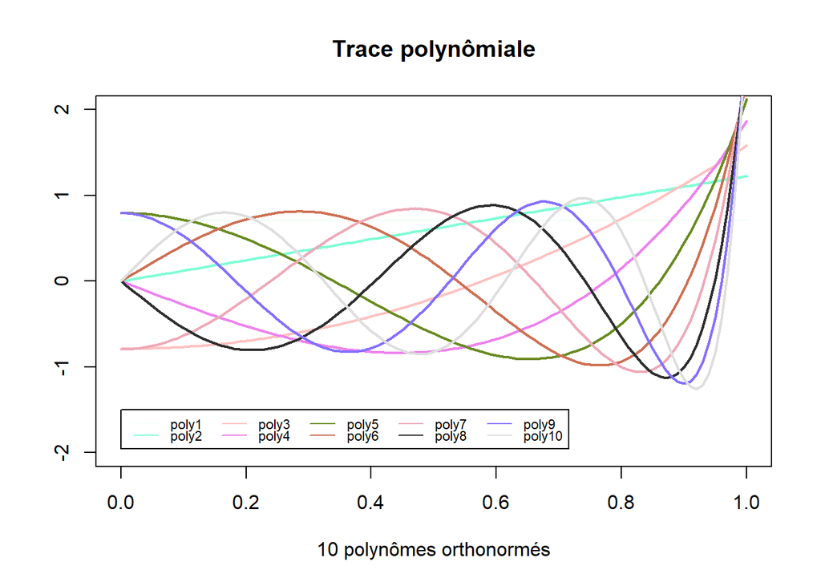

```r
invisible(sapply(1:10, function(i, ...) plot(BasePoly10[[i]], col = couleurs[i], add = (i != 1), ...),
                 xlim = c(0, 1), ylim = c(-2, 2), xlab = "10 polyn\U00F4mes orthonorm\U00E9s"))
legend(0, -1.5, inset = 0.05, legend = paste("poly", 1:10, sep = ""), col = couleurs,
       lwd = 1, xpd = TRUE, ncol = 5, y.intersp = 0.7, cex = 0.7)
```

### 19. Création d’une fonction qui fait la régression linéaire polynomiale à l’aide d’une base polynomiale donnée.

```r
regLinBaseQconq <- function(X, Y, Base) {
  if (!is.numeric(X) | !is.numeric(Y) | length(X) != length(Y)) stop("X et Y doivent être deux vecteurs numériques
     de même longueur !") else
  if (!is.list(Base)) stop("Base doit être soit une liste de polynômes soit une liste de functions !") else
  if (is.Polynomial(Base[[1]])) {
     Base <- lapply(Base, function(composante) return (function(x) values(composante, x)))
  }

  if (is.function(Base[[1]])) {
    lmFit <- lm(as.formula(paste("Y ~ 0", (paste("Base[[", 1:length(Base), "]](X)", sep="", collapse="+")), sep="+")))
  } else stop("La base entrée n'est ni de fonctions ni de polynômes !")
  ## Ici, je suis obsessif de fabriquer une formule plutôt que de créer une matrice avec une série de variables,
  ## pour que mon modèle à la fin reste un modèle entre X et Y. J'ai tout intérêt de faire ça comme ça car plus
  ## tard, quand je prédis pour n'importe quelle valeur de X entre [-1, 1], je pourrai prendre ce modèle calculé
  ## et lui donner directement la valeur du nouveau X. Sinon, je serais obligé de recalculer à chaque fois la
  ## matrice, si ce nouveau X n'appartient pas à l'ensemble des valeurs de X utilisées pour ajuster le modèle.

  names(lmFit$coefficients) <- paste("f_", 1:length(Base), "(X)", sep = "")
  return(lmFit)
}
```

### 20. Simulations d’un jeu de données.

```r
X1 <- runif(n = 100, min = -1, max = 1)
epsilon <- rnorm(n = 100)
Y1 <- sin(4 * pi * X1) + epsilon
head(X1)
```

```
## [1]  0.75561345 -0.66300659 -0.98870227  0.07787032 -0.93632592  0.01847782
```

```r
tail(Y1)
```

```
## [1] 0.4271366 0.5398039 2.9419518 0.8317565 0.4512893 2.0300651
```

### 21. Traces du nuage des points et les estimations des modèles avec des bases de 5, 10 et 15 composantes.

En faveur de l’exercice 22, j’ai emballé les étapes de tracer dans une fonction, qui prend comme paramètres entres autres un nombre quelconque de bases quelconques et le jeu de données.

```r
traceModelesAjustes <- function(newPar = c(2, 2), dimBases = c(5, 10, 15), FUN = basePolynomial,
                                Y = Y1, X = X1, ...) {
  FitListe <- lapply(dimBases, function(x) regLinBaseQconq(X, Y, FUN(x, ...)))
  XGrille = seq(-1, 1, by = 0.01)
  YPreditListe <- lapply(FitListe, function(Fit) predict(Fit, data.frame(X = XGrille)))
  oldPar <- par(mfrow = newPar)
  for (i in c(0, dimBases)) {
    plot(Y~X, pch = 16, col = "darkblue")
    plot(function(x) sin(4 * pi * x), xlim=(c(-1, 1)), add=TRUE, lwd=2, col="darkgreen")
    if (i > 0) {
      title(main = paste("Base", i))
      lines(XGrille, YPreditListe[[which(dimBases == i)]], lwd=2, col = "darkorange")
    } else
      title(main = "Jeu de donn\U{E9}es")
  }
  par(oldPar)
}
```

Essayons maintenant avec les 2 types de bases polynomiales

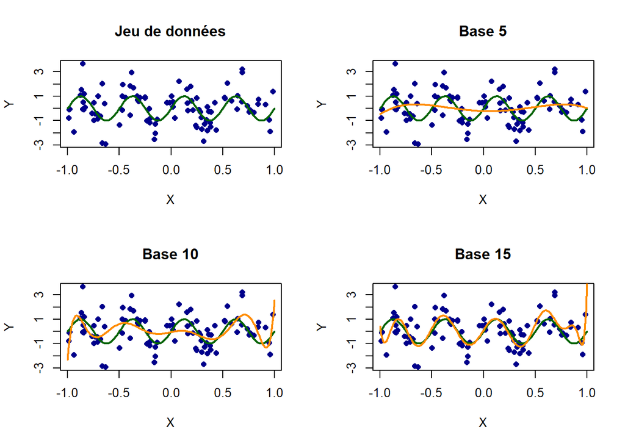

```r
traceModelesAjustes(ortho = TRUE)
```

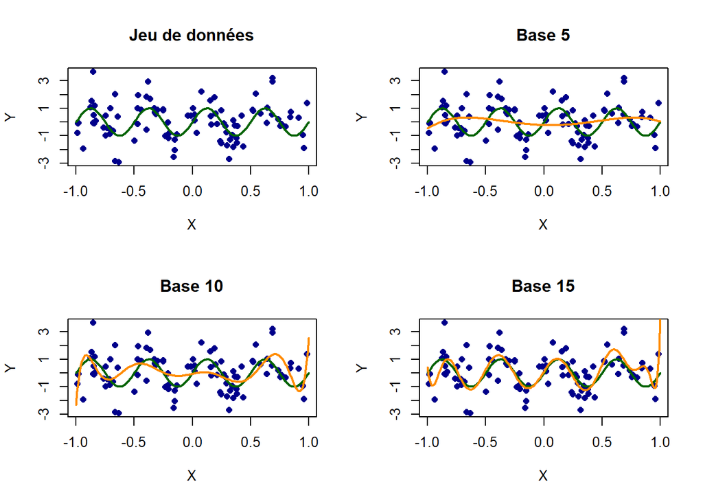

```r
traceModelesAjustes(ortho = FALSE)
```

```r
## Aucune différence que la précédente ? Forcément, car pour les modèles complets,
## l'espace vectoriel engendré par les deux types de bases est le même.
```

## Partie Bonus

### 22. Base sinusoïdale.

D’abord la fonction pour créer une base sinusoïdale de façon récursive.

```r
baseSinusoidale <- function(d) {
  return (if (d == 1) list(function(x) 0*x + 1/2) else c(baseSinusoidale(d-1), function(x) sin((d - 1/2) * pi * x)))
}
```

On essaie la fonction avec une base de 3 dimensions.

```r
BaseSin3 <- baseSinusoidale(3)
BaseSin3[[3]](c(1,2,3))
```

```
## [1]  1.000000e+00  6.123032e-16 -1.000000e+00
```

```r
BaseSin3[[2]](c(1,2,3))
```

```
## [1] -1.000000e+00  3.673819e-16  1.000000e+00
```

```r
BaseSin3[[1]](c(1,2,3))
```

```
## [1] 0.5 0.5 0.5
```

Maintenant on trace, grâce à la flexibilité de la fonction de plot créée à la question précédente, les modèles ajustés avec une base sinusoïdale de 1 - 11 dimensions.

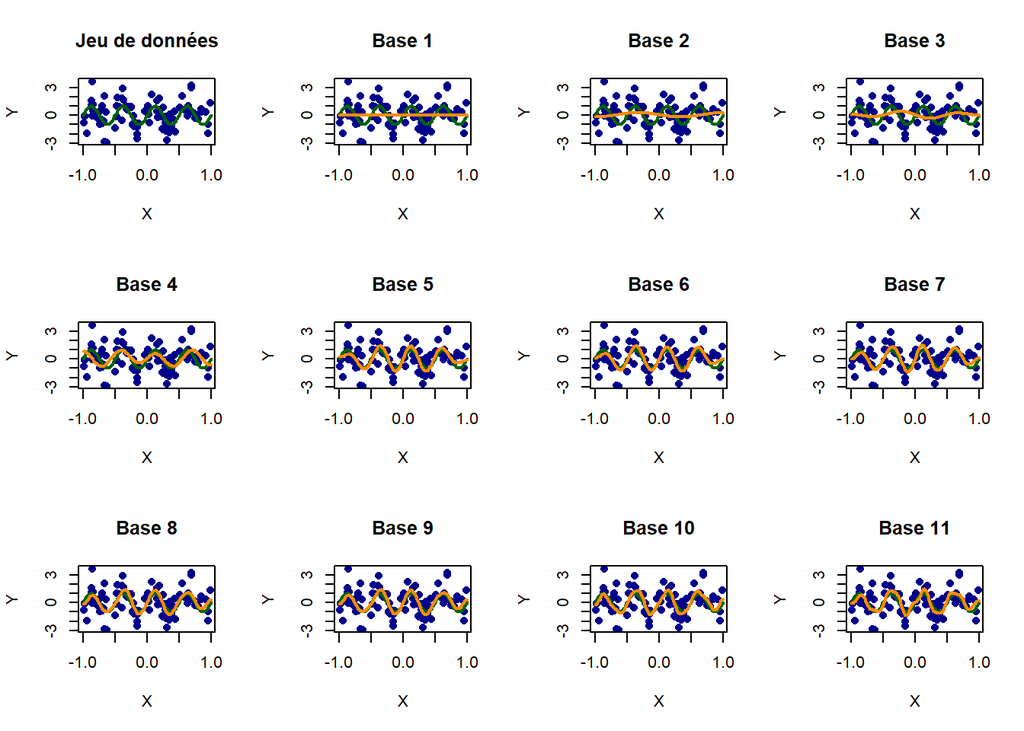

```r
traceModelesAjustes(newPar = c(3,4), dimBases = c(1:11), FUN = baseSinusoidale)
```

### 23. Sélection par Lasso.

Pour faire Lasso, j’utilise le paquet “glmnet” au lieu de “lars”, publié par Jérôme Friedman et al., dernière mise à jour le 30 avril 2017.

```r
#########################################################################################
# install.packages("glmnet") # Enlever le 1er '#' pour l'installation du paquet #########
#########################################################################################
library(glmnet)
```

**On traite d’abord la base polynomiale ortho-normée.**

Création d’une base polynomiale orthonormée de 20 dimensions (Par observation à l’oeil des graphiques précédentes et en prenant compte du petit nombre d’observations, on peut dire que 20 composantes suffirait pour faire la sélection des features).

```r
BasePolyOrtho20 <- basePolynomial(20, ortho = TRUE)
```

Création de la matrice à 20 variables (composantes de la base) et 100 lignes correspondant à chaque observation de X1.

```r
X1OrthoMatrice20 <- sapply(BasePolyOrtho20, function(composante) sapply(X1, function(x) values(composante, x)))
```

Changement de nom des variables pour éviter de longues expressions.

```r
colnames(X1OrthoMatrice20)  <- paste("Comp", 1:20, sep = "")
```

Une série de valeurs de lambda avec qui R va devoir résoudre Lasso. Ces valeurs sont choisies ultérieurement, sachant que lambda plus grand que 1 ne servant à rien dans ce cas.

```r
grillePolyOrtho <- 10^seq(0, -2, length = 100)
```

Maintenant la fonction glmnet va résoudre Lasso et renvoyer associée à chaque valeur de lambda une série de beta, coefficients de chaque variables, stockée dans une matrice accessible par la function “coef”. Ici il convient de remarquer deux choses. L’une est que “glmnet” ajoute automatiquement le terme constant qui ne peut pas être éteint en mettant “intercept = FALSE” ! Dans les anciennes versions de glmnet avant 2012 oui mais pas celles d’après. Ceci pourrait affecter fort le résultat de Lasso car la première composante elle aussi est constante (grave pour elle au moins). Mais vus les betas qu’on a obtenus au final, tant ceux associés au terme constant que ceux associés à la première composante restent tout le temps 0, on est tranquille. L’autre chose est que glmnet() fait par défaut la standardisation. Je ne vois pas de raison que celle-ci soit gênante donc je l’ai laissée.

```r
lassoPolyOrtho20 <- glmnet(X1OrthoMatrice20, Y1, intercept = FALSE, alpha = 1, lambda = grillePolyOrtho)
```

```r
summary(lassoPolyOrtho20)
```

```
##           Length Class     Mode
## a0         100   -none-    numeric
## beta      2000   dgCMatrix S4
## df         100   -none-    numeric
## dim          2   -none-    numeric
## lambda     100   -none-    numeric
## dev.ratio  100   -none-    numeric
## nulldev      1   -none-    numeric
## npasses      1   -none-    numeric
## jerr         1   -none-    numeric
## offset       1   -none-    logical
## call         6   -none-    call
## nobs         1   -none-    numeric
```

```r
coef(lassoPolyOrtho20)[, 30:35] # Sparse Matrix, . représente un 0.
```

```
## 21 x 6 sparse Matrix of class "dgCMatrix"
##                     s29         s30         s31         s32         s33
## (Intercept)  .           .           .           .           .
## Comp1        .           .           .           .           .
## Comp2        .           .           .           .           .
## Comp3        .           .           .           .           .
## Comp4        .           .           .           .           .
## Comp5        .           .           .           .           .
## Comp6        .           .           .           .           .
## Comp7        .           .           .           .           .
## Comp8        .           0.01600441  0.03309053  0.04940835  0.06498450
## Comp9        .           .           .           .           .
## Comp10       0.15415338  0.16978860  0.18479153  0.19913761  0.21283167
## Comp11       .           .           .           .           .
## Comp12      -0.43691539 -0.44785735 -0.45813667 -0.46793890 -0.47729558
## Comp13       0.04527398  0.05793369  0.06980848  0.08114019  0.09195686
## Comp14       0.05352380  0.07677349  0.09926782  0.12074377  0.14124361
## Comp15       .           .           .           .           .
## Comp16       .           .           .           .           .
## Comp17       .           .           .           .           .
## Comp18       .           .           .           .           .
## Comp19       .           .           .           .           .
## Comp20       .           .           .           .           .
##                     s34
## (Intercept)  .
## Comp1        .
## Comp2        .
## Comp3        .
## Comp4        .
## Comp5        .
## Comp6        .
## Comp7        .
## Comp8        0.07985269
## Comp9        .
## Comp10       0.22590332
## Comp11       .
## Comp12      -0.48622700
## Comp13       0.10228190
## Comp14       0.16081170
## Comp15       .
## Comp16       .
## Comp17       .
## Comp18       .
## Comp19       .
## Comp20       .
```

Maintenant pour tracer l’effet de la sélection contre les valeurs de log lambda, on charge le paquet `plotmo`.

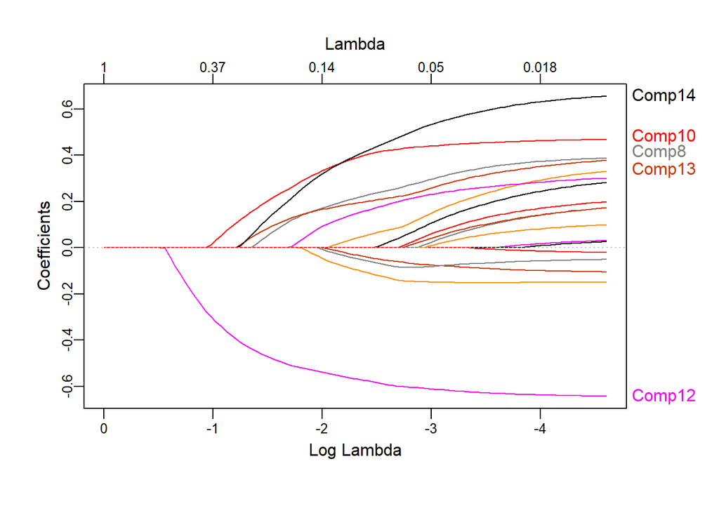

```r
#########################################################################################
# install.packages("plotmo") # Enlever le 1er '#' pour l'installation du paquet #########
#########################################################################################
library(plotmo)
plot_glmnet(lassoPolyOrtho20, label = 5) # libeller les 5 predicteurs les plus importants
```

Maintenant on met les autres variables en gris

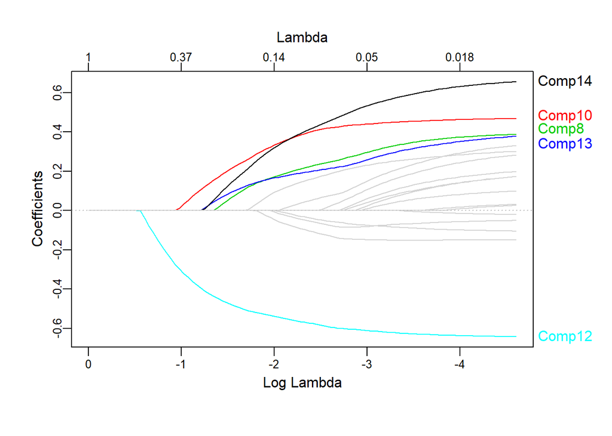

```r
randCol20 <- rep("lightgray", times = 20)
randCol20[c(1, 2, 3, 4, 18)] <- 1:5
plot_glmnet(lassoPolyOrtho20, label = 5, col = randCol20)
```

Pour savoir quelle est la valeur optimale de lambda, on peut faire une validation croisée à 5 plis. Cela peut être éffectué par la fonction `cv.glmnet` du paquet `glmnet`.

```r
cvPolyOrtho = cv.glmnet(X1OrthoMatrice20, Y1, alpha = 1, nfolds = 5) # alpha = 1 pour Lasso
summary(cvPolyOrtho)
```

```
##            Length Class  Mode
## lambda     67     -none- numeric
## cvm        67     -none- numeric
## cvsd       67     -none- numeric
## cvup       67     -none- numeric
## cvlo       67     -none- numeric
## nzero      67     -none- numeric
## name        1     -none- character
## glmnet.fit 12     elnet  list
## lambda.min  1     -none- numeric
## lambda.1se  1     -none- numeric
```

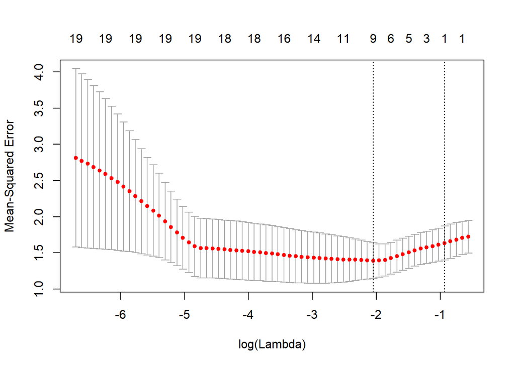

```r
plot(cvPolyOrtho)
```

```r
cvPolyOrtho$lambda.min # lambda optimal minimisant la MSE dans la vadilation croisée
```

```
## [1] 0.1288373
```

```r
dim(cvPolyOrtho$glmnet.fit$beta) # Combien de valeurs de lambda a-t-il testé en tout ?
```

```
## [1] 20 69
```

```r
cvPolyOrtho$glmnet.fit$beta[cvPolyOrtho$lambda == cvPolyOrtho$lambda.min] # les beta lorsque lambda prend sa valeur optimale
```

```
## <sparse>[ <logic> ] : .M.sub.i.logical() maybe inefficient
```

```
##  [1]  0.000000000  0.000000000  0.000000000  0.000000000 -0.015103320
##  [6] -0.539685402 -0.032633347 -0.072897756  0.294070651  0.090974157
## [11] -0.001123598  0.636986177  0.000000000  0.369372723  0.206446969
## [16]  0.314322946  0.112421132  0.035807930  0.066454535  0.486330877
## [21]  0.375954251
```

```r
sum(cvPolyOrtho$glmnet.fit$beta[cvPolyOrtho$lambda == cvPolyOrtho$lambda.min] != 0) # nombre de beta non nuls dans ce cas
```

```
## <sparse>[ <logic> ] : .M.sub.i.logical() maybe inefficient
```

```
## [1] 16
```

```r
min(cvPolyOrtho$cvm) # la MSE minimum
```

```
## [1] 1.391186
```

**Ensuite on traite la base plynomiale non-orthonormée, exactement de la même façon.**

Création d’une base polynomiale NON-orthonormée de 20 dimensions.

```r
BasePolyNONOrtho20 <- basePolynomial(20, ortho = FALSE)
```

Création de la matrice à 20 variables (composantes de la base) et 100 lignes correspondant à chaque observation de `X1`.

```r
X1NONOrthoMatrice20 <- sapply(BasePolyNONOrtho20, function(composante) sapply(X1, function(x) values(composante, x)))
```

Changement de nom des variables pour éviter de longues expressions.

```r
colnames(X1NONOrthoMatrice20)  <- paste("Comp", 1:20, sep = "")
```

Une série de valeurs de lambda avec qui R va devoir résoudre Lasso.

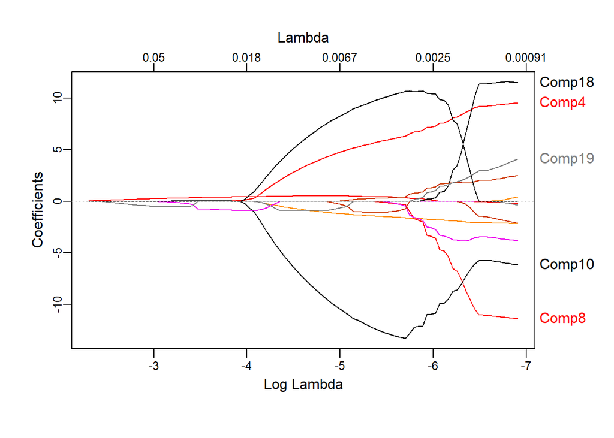

```r
grillePolyNONOrtho <- 10^seq(-1, -3, length = 100)
lassoPolyNONOrtho20 <- glmnet(X1NONOrthoMatrice20, Y1, intercept = FALSE, alpha = 1, lambda = grillePolyNONOrtho)
plot_glmnet(lassoPolyNONOrtho20, label = 5)
```

Pour savoir quelle est la valeur optimale de lambda, on peut faire une validation croisée à 5 plis. Cela peut être éffectué par la fonction `cv.glmnet`.

```r
cvPolyNONOrtho = cv.glmnet(X1NONOrthoMatrice20, Y1, alpha = 1, nfolds = 5)
summary(cvPolyNONOrtho)
```

```
##            Length Class  Mode
## lambda     57     -none- numeric
## cvm        57     -none- numeric
## cvsd       57     -none- numeric
## cvup       57     -none- numeric
## cvlo       57     -none- numeric
## nzero      57     -none- numeric
## name        1     -none- character
## glmnet.fit 12     elnet  list
## lambda.min  1     -none- numeric
## lambda.1se  1     -none- numeric
```

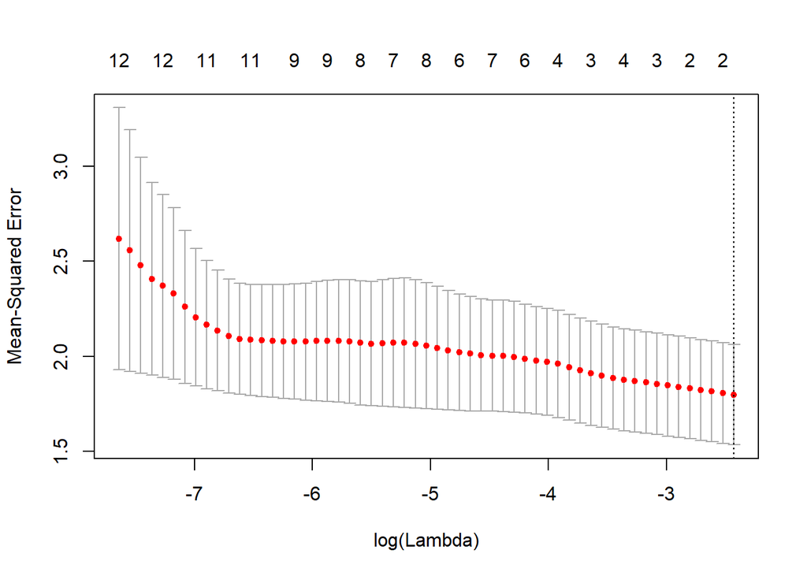

```r
plot(cvPolyNONOrtho)
```

```r
cvPolyNONOrtho$lambda.min # lambda optimal minimisant la MSE dans la vadilation croisée
```

```
## [1] 0.08809074
```

```r
dim(cvPolyNONOrtho$glmnet.fit$beta) # Combien de valeurs de lambda a-t-il testé en tout ?
```

```
## [1] 20 61
```

```r
cvPolyNONOrtho$glmnet.fit$beta[, cvPolyNONOrtho$lambda == cvPolyNONOrtho$lambda.min] # les beta lorsque lambda prend sa valeur optimale
```

```
## 20 x 2 sparse Matrix of class "dgCMatrix"
##        s0         s57
## Comp1   .   .
## Comp2   .  -1.6792657
## Comp3   .   0.7291276
## Comp4   .   .
## Comp5   .   0.3416989
## Comp6   .  42.2208905
## Comp7   .   1.0332272
## Comp8   . -66.4153608
## Comp9   .   0.8555026
## Comp10  .   .
## Comp11  .   .
## Comp12  .   .
## Comp13  .   .
## Comp14  .  13.4106830
## Comp15  . -16.7821591
## Comp16  .  32.2812301
## Comp17  .   .
## Comp18  .   .
## Comp19  .  14.4186290
## Comp20  . -18.4511102
```

```r
sum(cvPolyNONOrtho$glmnet.fit$beta[, "s56"] != 0) # nombre de beta non nuls dans ce cas
```

```
## [1] 12
```

```r
min(cvPolyNONOrtho$cvm) # la MSE minimum
```

```
## [1] 1.797083
```

**Enfin on traite la base sinusoïdale.**

Création d’une base sinusoïdale de 20 dimensions.

```r
BaseSin20 <- baseSinusoidale(20)
```

Création de la matrice à 20 variables (composantes de la base) et 100 lignes correspondant à chaque observation de X1.

```r
X1SinMatrice20 <- sapply(BaseSin20, function(composante) sapply(X1, function(x) composante(x)))
```

Changement de nom des variables pour éviter de longues expressions.

```r
colnames(X1SinMatrice20)  <- paste("Comp", 1:20, sep = "")
```

Une série de valeurs de lambda avec qui R va devoir résoudre Lasso.

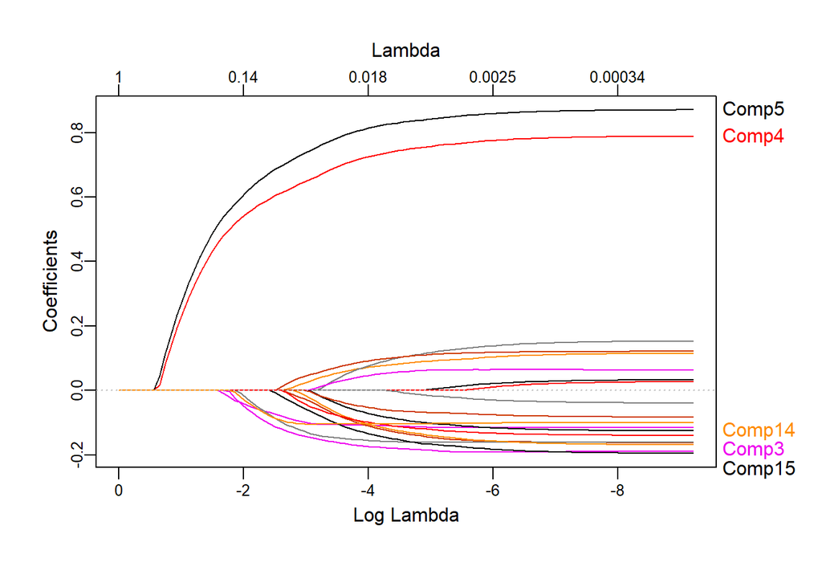

```r
grilleSin <- 10^seq(0, -4, length = 100)
lassoSin20 <- glmnet(X1SinMatrice20, Y1, intercept = FALSE, alpha = 1, lambda = grilleSin)
plot_glmnet(lassoSin20, label = 5)
```

Pour savoir quelle est la valeur optimale de lambda, on peut faire une validation croisée à 5 plis. Cela peut être éffectué par la fonction `cv.glmnet`.

```r
cvSin = cv.glmnet(X1SinMatrice20, Y1, alpha = 1, nfolds = 5)
summary(cvSin)
```

```
##            Length Class  Mode
## lambda     66     -none- numeric
## cvm        66     -none- numeric
## cvsd       66     -none- numeric
## cvup       66     -none- numeric
## cvlo       66     -none- numeric
## nzero      66     -none- numeric
## name        1     -none- character
## glmnet.fit 12     elnet  list
## lambda.min  1     -none- numeric
## lambda.1se  1     -none- numeric
```

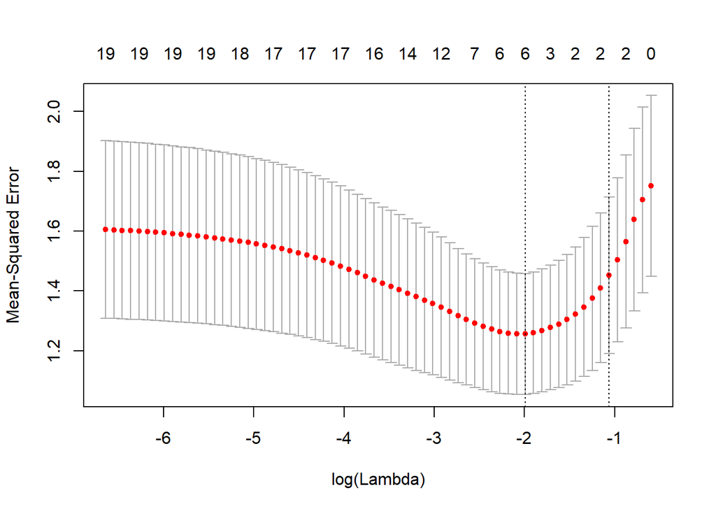

```r
plot(cvSin)
```

```r
cvSin$lambda.min # lambda optimal minimisant la MSE dans la vadilation croisée
```

```
## [1] 0.1364502
```

```r
dim(cvSin$glmnet.fit$beta) # Combien de valeurs de lambda a-t-il testé en tout ?
```

```
## [1] 20 71
```

```r
cvSin$glmnet.fit$beta[, cvSin$lambda == cvSin$lambda.min] # les beta lorsque lambda prend sa valeur optimale
```

```
##       Comp1       Comp2       Comp3       Comp4       Comp5       Comp6
##  0.00000000  0.00000000 -0.04861502  0.54261984  0.60054502  0.00000000
##       Comp7       Comp8       Comp9      Comp10      Comp11      Comp12
##  0.00000000 -0.05267948  0.00000000  0.00000000 -0.01701219  0.00000000
##      Comp13      Comp14      Comp15      Comp16      Comp17      Comp18
##  0.00000000  0.00000000  0.00000000  0.00000000  0.00000000  0.00000000
##      Comp19      Comp20
##  0.00000000 -0.01854741
```

```r
sum(cvSin$glmnet.fit$beta[, cvSin$lambda == cvSin$lambda.min] != 0) # nombre de beta non nuls dans ce cas
```

```
## [1] 6
```

On voit que la base sinusoïdale n’a besoin que de la moitié de prédicteurs par rapport aux deux autres bases pour expliquer les données,

```r
min(cvSin$cvm) # et que sa MSE est mieux aussi !
```

```
## [1] 1.256034
```

**On aimerais illustrer les MSEs estimées par la validation croisée de ces trois modèles contre log lambda dans un plot.**

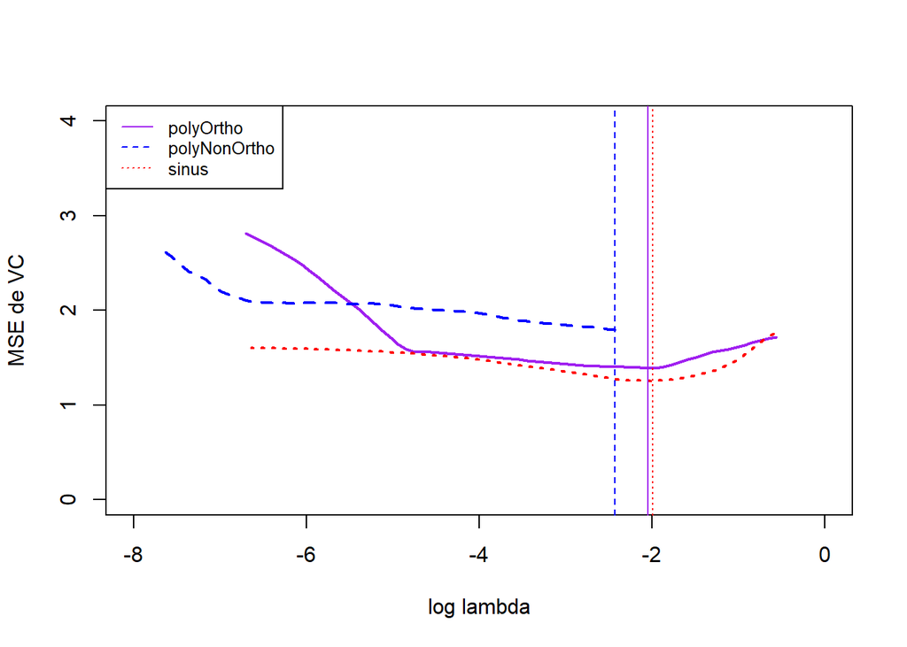

```r
plot(1, 1, xlim = c(-8, 0), ylim = c(0, 4), xlab = "log lambda", ylab = "MSE de VC", type = 'n')
lines(log(cvPolyOrtho$lambda), cvPolyOrtho$cvm, col="purple", lwd = 2, lty = 1)
lines(log(cvPolyNONOrtho$lambda), cvPolyNONOrtho$cvm, col="blue", lwd = 2, lty = 2)
lines(log(cvSin$lambda), cvSin$cvm, col="red", lwd = 2, lty = 3)
abline(v=log(c(cvPolyOrtho$lambda.min, cvPolyNONOrtho$lambda.min, cvSin$lambda.min)), col = c('purple', 'blue', 'red'),
       lty = 1:3, lwd = 1) # positions optimales par validation croisée
legend("topleft", c("polyOrtho", "polyNonOrtho", "sinus"), lty = 1:3, col = c('purple', 'blue', 'red'), cex = 0.8)
```

**Maintenant, on mesurerera la performance des 3 méthodes sur un jeu de données de test.** On aurait dû couper le jeu de données originel en 2 avant d’ajuster nos modèles ; mais comme les données sont simulées et rien ne nous empêche d’en simuler beaucoup d’autres. On va donc créer un jeu de données de test de même taille de la même façon.

Remarque : pour évaluer ces trois modèles, il suffit dans notre situation de comparer les valeurs prédites resp. par chaque modèle avec la vraie fonction sous-jacente. Mais comme ceci n’est jamais possible en pratique, on prend tout de même un jeu de données de test et on plotte les graphiques de la MSE de test.

Génération d’un autre jeu de données contenant 100 observations, de la même façon qu’avant.

```r
X2 <- runif(n = 100, min = -1, max = 1)
epsilon2 <- rnorm(n = 100)
Y2 <- sin(4 * pi * X2) + epsilon2
```

On l’illustre ensemble avec l’ancien jeu de données.

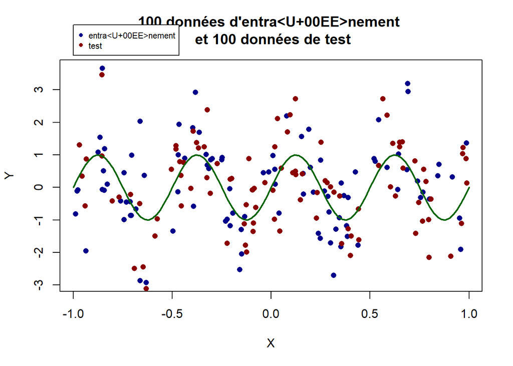

```r
plot(Y1~X1, pch = 16, col = "darkblue", main = "100 données d'entraînement \n et 100 données de test",
     xlab = "X", ylab = "Y")
points(Y2~X2, pch = 16, col = "darkred")
plot(function(x) sin(4 * pi * x), xlim=(c(-1, 1)), add=TRUE, lwd=2, col="darkgreen")
legend(x = -1, y = 5, c("entraînement", "test"), pch = 16, col = c("darkblue", "darkred"), cex = 0.7, xpd = TRUE)
```

Il vaut mieux avoir une série de valeurs de lambda commune significative pour toutes les trois bases

```r
grilleCommune <- 10^seq(0, -4, length = 200)
```

On prédit les réponses de test en prenant le modèle de Lasso ajusté à travers les données d’entraînement et calcule la MSE de test pour la base polynomiale ortho-normée

```r
X2OrthoMatrice20 <- sapply(BasePolyOrtho20, function(composante) sapply(X2, function(x) values(composante, x)))
predOrtho <- predict(lassoPolyOrtho20, s=grilleCommune, newx = X2OrthoMatrice20)
MSEOrtho <- apply(predOrtho, 2, function(x) mean((x - Y2)^2))
```

On en fait du pareil avec la base polynomiale non-ortho-normée

```r
X2NONOrthoMatrice20 <- sapply(BasePolyNONOrtho20, function(composante) sapply(X2, function(x) values(composante, x)))
predNONOrtho <- predict(lassoPolyNONOrtho20, s=grilleCommune, newx = X2NONOrthoMatrice20)
MSENONOrtho <- apply(predNONOrtho, 2, function(x) mean((x - Y2)^2))
```

On en fait du pareil avec la base sinusoïdale

```r
X2SinMatrice20 <- sapply(BaseSin20, function(composante) sapply(X1, function(x) composante(x)))
predSin <- predict(lassoSin20, s=grilleCommune, newx = X2SinMatrice20)
MSESin <- apply(predSin, 2, function(x) mean((x - Y2)^2))
```

Et on plotte les courbes de MSE de test pour les trois bases ainsi que leurs positions optimales estimées

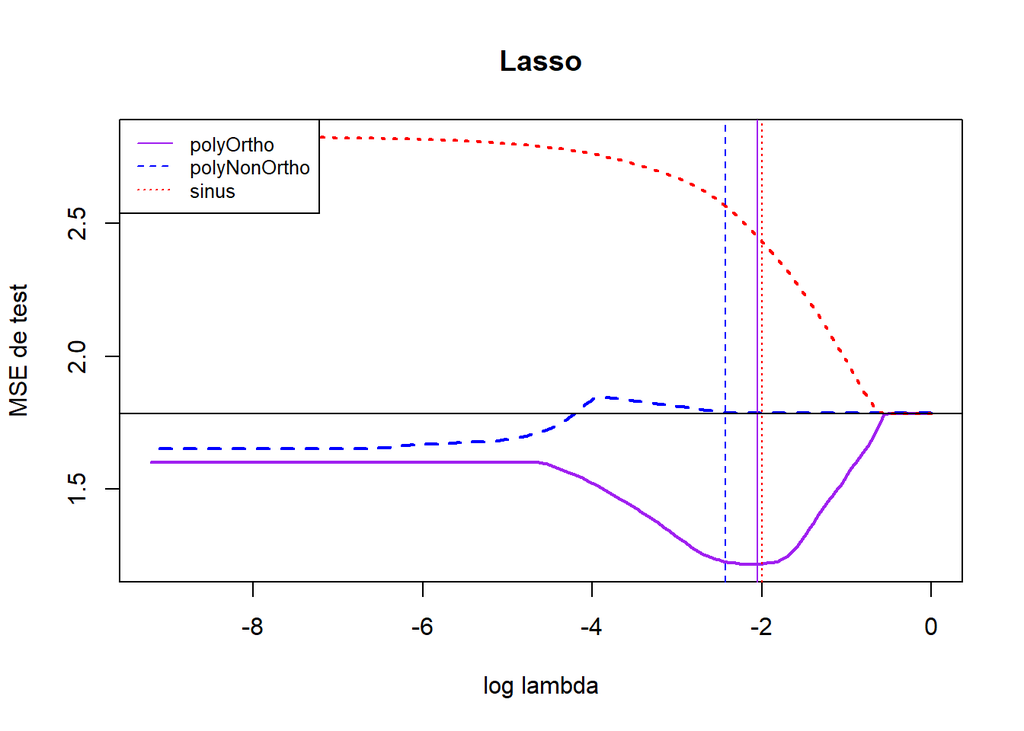

```r
matplot(log(grilleCommune), cbind(MSEOrtho, MSENONOrtho, MSESin), col = c('purple', 'blue', 'red'), type = 'l', lwd = 2,
        xlab = "log lambda", ylab = "MSE de test", main = "Lasso")
abline(v = log(c(cvPolyOrtho$lambda.min, cvPolyNONOrtho$lambda.min, cvSin$lambda.min)), col = c('purple', 'blue', 'red'),
       lty = 1:3, lwd = 1)
abline(h = mean((Y2 - mean(Y1))^2)) ## droite sur laquelle se réunissent les 3 MSE lorque lambda devient grand,
## aussi la MSE qu'on aura quand on prédit pour n'importe quelle valeur de X entre [-1, 1] avec la moyenne de Y1.
legend("topleft", c("polyOrtho", "polyNonOrtho", "sinus"), lty = 1:3, col = c('purple', 'blue', 'red'), cex = 0.8)
```

**De façon étonnante, la base sinusoïdale a joué le pire, même beaucoup pire que l’estimation banale par la moyenne de `Y1`, contrairement au résultats qu’on a eus avec la validation croisée. La base polynomiale ortho-normée est la meilleure, en plus son estimation de la valeur de lambda optimale est assez exacte. Quelle en est la raison ?**

## Références

**[1]** *Gareth James et al. (2013)*, An Introduction to Statistical Learning with Applications in R.

**[2]** *Hadley Wickham (2014)*, Advanced R.

```r
## ANNEXE : Les opérations arithmétiques que j'ai faites séparément à la première fois
## Rappelez-vous du paramètre "d'en trop" "degreVoulu" dans la fonction simplifyPolynomial(), dont le but est de
## compléter un polynôme avec des 0 à un degré donné plus élevé que celui du polynôme. Maintenant on va s'en
## servir pour éviter le mécanisme du recyclage des opérations vectorielles de R.

# ## Addition.
# setMethod(
#   f = `+`,
#   signature (e1 = "Polynomial", e2 = "Polynomial"),
#   definition = `+.Polynomial` <- function(e1, e2) {
#     if (missing(e2)) resultat_coeffs <- callGeneric(e1@coeffs) else {
#       maxDeg <- max(degre(e1), degre(e2))
#       e1 <- simplifyPolynomial(e1, degreVoulu = maxDeg)
#       e2 <- simplifyPolynomial(e2, degreVoulu = maxDeg)
#       resultat_coeffs <- callGeneric(e1@coeffs, e2@coeffs)
#     }
#     return (simplifyPolynomial(Polynomial(resultat_coeffs)))
#   }
# )
#
# poly1 ; poly2
# poly1 + poly2
# + poly2
# + poly0
# poly0 + poly0
#
# ## Soustraction. Exactement le même code sauf "-" au lieu de "+".
# setMethod(
#   f = `-`,
#   signature (e1 = "Polynomial", e2 = "Polynomial"),
#   definition = `-.Polynomial` <- function(e1, e2) {
#     if (missing(e2)) resultat_coeffs <- callGeneric(e1@coeffs) else {
#       maxDeg <- max(degre(e1), degre(e2))
#       e1 <- simplifyPolynomial(e1, degreVoulu = maxDeg)
#       e2 <- simplifyPolynomial(e2, degreVoulu = maxDeg)
#       resultat_coeffs <- callGeneric(e1@coeffs, e2@coeffs)
#     }
#     return (simplifyPolynomial(Polynomial(resultat_coeffs)))
#   }
# )
#
# poly1 ; poly2
# poly1 - poly2
# - poly2
# - poly0
# poly0 - poly0
#
# ## Multiplication. Il y a des algorithmes efficaces dédiés au calcul de la multiplication polynomiale
# ## en informatique, e.g. celui de "diviser pour régner". Ici on ne va pas le faire, puisque
# ## 1. R n'est de toute façon pas un logiciel très efficace, d'où de couper un polynôme en morceaux va prendre du temps ;
# ## 2. On ne va pas faire de la multiplication avec des polynômes gigantesques, le temps gagné sera pas remarquable.
# ## Donc ici, on le fait avec des boules.
#
# setMethod(
#   f = `*`,
#   signature (e1 = "Polynomial", e2 = "Polynomial"),
#   definition = `-.Polynomial` <- function(e1, e2) {
#     Deg1 <- degre(e1)
#     Deg2 <- degre(e2)
#     if (Deg1 == -Inf || Deg2 == -Inf) return (Polynomial(0)) else {
#       DegResultat <- Deg1 + Deg2
#       coeffs1 <- simplifyPolynomial(e1)@coeffs
#       coeffs2 <- simplifyPolynomial(e2)@coeffs
#       resultat_coeffs <- numeric(DegResultat + 1)
#       for (i in 1:(Deg1+1))
#         for (j in 1:(Deg2+1))
#           resultat_coeffs[i+j-1] <- resultat_coeffs[i+j-1] + coeffs1[i] * coeffs2[j]
#       return (Polynomial(resultat_coeffs))
#     }
#   }
# )
# poly1; poly2
# poly1 * poly2
# poly0 * poly0
# poly0 * poly1
#
# ## Calcul du residu.
# setMethod(
#   f = `%/%`,
#   signature (e1 = "Polynomial", e2 = "Polynomial"),
#   definition = `%/%.Polynomial` <- function(e1, e2) {
#     if (degre(e2) == -Inf) stop("Diviseur ne doit pas être nul !") else
#       if (degre(e2) == 0) return (Polynomial(0)) else {
#         coeffs1 <- simplifyPolynomial(e1)@coeffs
#         coeffs2 <- simplifyPolynomial(e2)@coeffs
#         if (length(coeffs1) < length(coeffs2) || length(coeffs1) == 0) {
#           e1@racines <- NA_integer_
#           return (simplifyPolynomial(e1))
#         } else {
#           e1@coeffs <- coeffs1 - c(rep(0, length(coeffs1) - length(coeffs2)),
#                                    tail(coeffs1, 1) / tail(coeffs2, 1) * coeffs2)
#           return (`%/%.Polynomial`(simplifyPolynomial(e1), e2))
#         }
#       }
#   }
# )
#
# Polynomial(c(1, 3, -1, 1), roots = TRUE) %/% Polynomial(c(5, 10, 5))
# Polynomial(c(1, 0, -2, 0, 0, 3, -5, -6, -8)) %/% Polynomial(c(3, -5, -6, -8))
# poly1
# poly1 %/% Polynomial(2)
# # poly1 %/% poly0
#
# ## Calcul du quotient.
# setMethod(
#   f = `%%`,
#   signature (e1 = "Polynomial", e2 = "Polynomial"),
#   definition = `%%.Polynomial` <- function(e1, e2) {
#     if (degre(e2) == -Inf) stop("Diviseur ne doit pas être nul !") else {
#       coeffs1 <- simplifyPolynomial(e1)@coeffs
#       coeffs2 <- simplifyPolynomial(e2)@coeffs
#       if (length(coeffs1) < length(coeffs2) || (length(coeffs1) == 1 && coeffs1[1] == 0)) return (Polynomial(0)) else {
#         Deg_diff <- length(coeffs1) - length(coeffs2)
#         Quotient_coeff_dominant <- tail(coeffs1, 1) / tail(coeffs2, 1)
#         e1@coeffs <- coeffs1 - c(rep(0, Deg_diff), Quotient_coeff_dominant * coeffs2)
#         return (Polynomial(c(rep(0, Deg_diff), Quotient_coeff_dominant)) +
#                   `%%.Polynomial`(simplifyPolynomial(e1), e2))
#       }
#     }
#   }
# )
#
# Polynomial(c(1, -1, 1), roots = TRUE) %% Polynomial(c(1, 1), roots = TRUE)
# Polynomial(c(1, 0, -2, 0, 0, 3, -5, -6, -8)) %% Polynomial(c(3, -5, -6, -8))
# poly1
# poly1 %% Polynomial(2)
# # poly1 %% poly0
#
# ## D'abord au lieu de convertir à chaque fois le diviseur numérique en polynôme puis faire la division polynomiale,
# ## il convient de définir la division d'un polynôme par un nombre, pour des raisons d'efficacité de calcul.
# setMethod(
#   f = `/`,
#   signature (e1 = "Polynomial", e2 = "numeric"),
#   definition = function(e1, e2) {
#     if (e2 == 0) stop("Diviseur ne doit pas être nul !") else {
#       e1@coeffs <- e1@coeffs / e2
#       return (simplifyPolynomial(e1))
#     }
#   }
# )
# poly1 / 0.5
#
# ## Il s'en va de même pour la multiplication par un nombre.
# setMethod(
#   f = `*`,
#   signature (e1 = "Polynomial", e2 = "numeric"),
#   definition = function(e1, e2) {
#     e1@coeffs <- e1@coeffs * e2
#     return (simplifyPolynomial(e1))
#   }
# )
# poly2 * 2
#
# setMethod(
#   f = "*",
#   signature (e1 = "numeric", e2 = "Polynomial"),
#   definition = function(e1, e2) {
#     e2@coeffs <- e1 * e2@coeffs
#     return (simplifyPolynomial(e2))
#   }
# )
# 2 * poly2
```